# Trabajo Practico Final - Ciencia de Datos II

Ahora descargamos el polígono para una mayor comprensión del territorio del partido.

```r
polygon_Lanus <- getbb("Partido de Lanús, Buenos Aires, Argentina",
                            format_out = "sf_polygon")
```

Veamos el resultado.

```r
polygon_Lanus
```

```
## Simple feature collection with 1 feature and 13 fields
## Geometry type: POLYGON
## Dimension:     XY
## Bounding box:  xmin: -58.4469 ymin: -34.74552 xmax: -58.33348 ymax: -34.65879
## Geodetic CRS:  WGS 84
##   place_id
## 1 17200020
##                                                                 licence
## 1 Data © OpenStreetMap contributors, ODbL 1.0. http://osm.org/copyright
##   osm_type  osm_id         lat         lon    class           type place_rank
## 1 relation 1421519 -34.7020514 -58.3995209 boundary administrative         10
##   importance    addresstype             name
## 1  0.4814313 state_district Partido de Lanús
##                                display_name                       geometry
## 1 Partido de Lanús, Buenos Aires, Argentina POLYGON ((-58.4469 -34.6886...
```

Y lo visualizamos. Para esta visualización quite el relleno del polígono y agregue un borde marcando el límite del partido.

```
## replace the existing one.
```

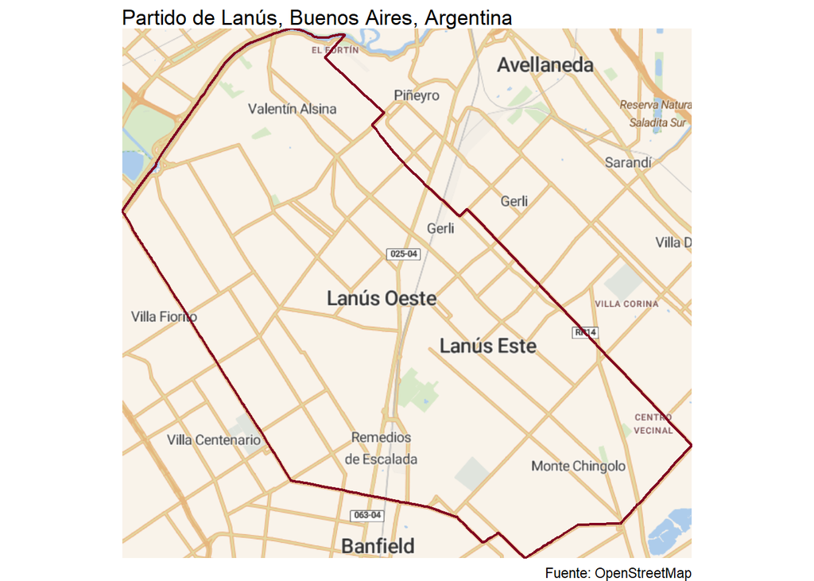

```r
ggmap(mapa_Lanus)+
  geom_sf(data=polygon_Lanus, fill=NA, color="#800020", lwd=0.75, inherit.aes = FALSE)+
  labs(title="Partido de Lanús, Buenos Aires, Argentina",
       caption="Fuente: OpenStreetMap") +
  theme_void()
```

Vamos a ver como queda el mapa con todos las capas.

```
## replace the existing one.
```

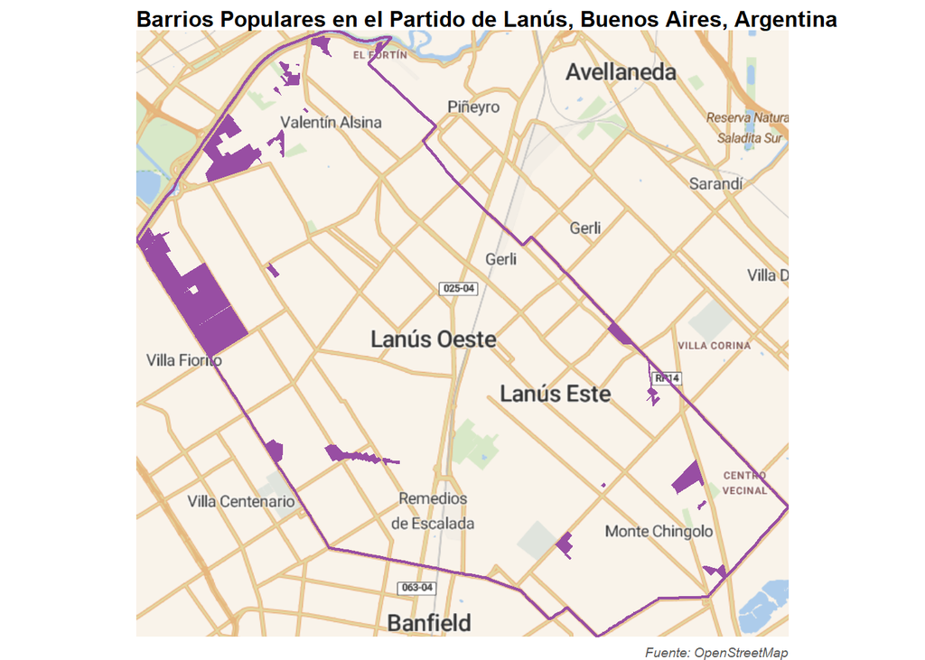

```r
ggmap(mapa_Lanus)+
  geom_sf(data=popular_Lanus, fill="#984ea3", color=NA, inherit.aes = FALSE) +
  geom_sf(data=polygon_Lanus, fill=NA, color="#984ea3", lwd=0.75, inherit.aes = FALSE) +
 labs(title="Barrios Populares en el Partido de Lanús, Buenos Aires, Argentina",
       caption="Fuente: OpenStreetMap")+
  theme_void()+
  theme(title=element_text(size=10, face = "bold"),
        plot.caption=element_text(face = "italic", colour = "gray35",size=7))
```

Aqui vemos la proporción de superficie m2 por cantidad de viviendas.

```
## replace the existing one.
```

[figure not shown]

```r
ggmap(mapa_Lanus) +
  geom_sf(data = popular_Lanus,
          aes(fill = superficie_m2/cantidad_viviendas_aproximadas),
          color = NA,
          inherit.aes = FALSE) +
  geom_sf(data = polygon_Lanus, fill = NA, color = "black", lwd = 0.75, inherit.aes = FALSE) +
  scale_fill_viridis_c(option = "magma",
                       name = "Superficie m2",
                       labels = scales::comma) +
  labs(title = "Superficie de barrio por cantidad de viviendas",
       caption = "Fuente: OpenStreetMap") +
  theme_void() +
  theme(title = element_text(size = 10, face = "bold"),
        plot.caption = element_text(face = "italic", colour = "gray35", size = 7),
        legend.position = "right")
```

**Claramente vemos que Villa Jardín es uno de los barrios más densamente poblados por la inmensa cantidad de viviendas que tiene**

Filtramos el barrio de nuestra dataset de Lanús.

```r
villa_Jardin <- popular_Lanus%>%
  filter(nombre_barrio == "Villa Jardín")
villa_Jardin
```

```
## Simple feature collection with 1 feature and 17 fields
## Geometry type: MULTIPOLYGON
## Dimension:     XY
## Bounding box:  xmin: -58.43537 ymin: -34.68052 xmax: -58.4249 ymax: -34.67061
## Geodetic CRS:  WGS 84
##   id_renabap nombre_barrio    provincia departamento   localidad
## 1       1012  Villa Jardín Buenos Aires        Lanús Lanús Oeste
##   cantidad_viviendas_aproximadas cantidad_familias_aproximada
## 1                           4500                         4950
##   decada_de_creacion anio_de_creacion           energia_electrica
## 1        Década 1940               NA Conexión irregular a la red
##                      efluentes_cloacales                      agua_corriente
## 1 Desagüe sólo a pozo negro/ciego u hoyo Conexión irregular a la red de agua
##           cocina       calefaccion titulo_propiedad clasificacion_barrio
## 1 Gas en garrafa Energía eléctrica               NO                Villa
##   superficie_m2                           geom
## 1        426815 MULTIPOLYGON (((-58.4309 -3...
```

y veamoslo en un mapa interactivo usando Leaflet usando la información geográfica de Villa Jardín.

```r
leaflet(villa_Jardin) %>%
  addProviderTiles("CartoDB.Positron") %>%
  addPolygons(popup = "Villa Jardín")
```

[interactive chart not shown]

Bien! sabemos que la geolocalizacion fue exitosa ya que el lugar es correcto, pertenece a Villla Jardín.

Ahora abriremos el dataset de hospitales públicos.

```r
hospitales <- read.csv("Datos/establecimientos_salud_publicos-2025.csv",
                  header = TRUE,
                  sep = ";",
                  encoding = "UTF-8",
                  stringsAsFactors = TRUE)
```

Vemos su composicion;

```r
dim(hospitales)
```

```
## [1] 3052   20
```

Tiene 3052 registros y 20 variables que representan todos los centros de salud de la provincia de Buenos Aires

Los nombres de las variables son las siguientes:

```r
names(hospitales)
```

```
##  [1] "id"   "lat"  "long" "cat"  "nor"  "cpd"  "cnr"  "cde"  "nde"  "dom"
## [11] "nba"  "nrs"  "cp1"  "tel"  "mai"  "tes"  "Com"  "Dep"  "mod"  "Esp"
```

vemos el resumen estadístico.

```r
summary(hospitales)
```

```
##        id              lat              long
##  Min.   :   1.0   Min.   :-40.81   Min.   :-63.38
##  1st Qu.: 763.8   1st Qu.:-36.08   1st Qu.:-60.21
##  Median :1526.5   Median :-34.80   Median :-58.75
##  Mean   :1526.5   Mean   :-35.46   Mean   :-59.35
##  3rd Qu.:2289.2   3rd Qu.:-34.58   3rd Qu.:-58.38
##  Max.   :3052.0   Max.   :-33.31   Max.   :-56.68
##
##                                                                   cat
##  C.A.P.S.                                                           :2121
##  ESTABLECIMIENTO POLIVALENTE CON INTERNACION Y PRESTACIÓN QUIRURGICA: 273
##  CENTRO DE SALUD MENTAL Y/O CONSUMOS PROBLEMATICOS                  : 162
##  RESIDENCIA PARA ADULTOS MAYORES                                    : 147
##  UNIDAD MOVIL                                                       :  72
##  VACUNATORIO                                                        :  52
##  (Other)                                                            : 225
##                             nor            cpd                    cnr
##  HOGAR GERIATRICO             :   5   Min.   :  642708   5,00606E+13: 125
##  CAPS SAN CAYETANO            :   4   1st Qu.:26000082   5,00643E+13: 122
##  CENTRO INTEGRADOR COMUNITARIO:   4   Median :44100166   5,00641E+13: 103
##  HOGAR DE ANCIANOS            :   4   Mean   :44163274   5,00627E+13:  88
##  CENTRO PROVINCIAL DE ATENCIÓN:   3   3rd Qu.:63800005   5,00644E+13:  88
##  C.A.P.S. AMEGHINO            :   2   Max.   :88568009   5,00636E+13:  83
##  (Other)                      :3030                      (Other)    :2443
##       cde                        nde                       dom
##  Min.   :  6.0   LA PLATA          : 115   129 51 53 0       :  17
##  1st Qu.:260.0   LA MATANZA        :  90   ZONA RURAL   0    :  17
##  Median :441.0   GENERAL PUEYRREDON:  75   PLANTA URBANA   0 :  11
##  Mean   :441.6   BAHIA BLANCA      :  73   SIN DATO   0      :   6
##  3rd Qu.:638.0   LOMAS DE ZAMORA   :  72   51   249          :   5
##  Max.   :885.0   QUILMES           :  71   RUTA 11 KM 111   0:   5
##                  (Other)           :2556   (Other)           :2991
##                nba            nrs           cp1
##  BAHIA BLANCA    :  66   VI     :494   Min.   :1602
##  MAR DEL PLATA   :  66   V      :480   1st Qu.:1804
##  LA PLATA        :  46   XI     :330   Median :2715
##  FLORENCIO VARELA:  45   VII    :284   Mean   :4152
##  JOSE C. PAZ     :  45   I      :276   3rd Qu.:7000
##  CAMPANA         :  35   VIII   :273   Max.   :8512
##  (Other)         :2749   (Other):915   NA's   :1
```

[output cut: 17 more lines]

```
##                      :  50   ASISTENCIAL COMPLEMENTARIO : 227
##  Fuerzas Armadas     :   3   ASISTENCIAL CON INTERNACION: 291
##  Fuerzas de Seguridad:  92   ASISTENCIAL SIN INTERNACION:2534
##  Ministerio de Salud : 334
##  Otro                :  12
##  Secretaria de Salud :2554
##  Universidad         :   7
##                                       Esp
##  DISCAPACIDAD                           :  41
##  GENERAL                                :2677
##  SALUD MENTAL Y/O CONSUMOS PROBLEMATICOS: 184
##  TERCERA EDAD                           : 150
##
##
##
```

Podemos ver:

- La categoría que predomina son los Centros de Atencion Primaria de la Salud (C.A.P.S.) con un total de 2,121 registros.
- La mayoría es de origen municipal con 2,558 registros.
- La mayoría de establecimientos de salud se encuentran en La Plata con un total de 115 registros.

Aqui vamos a filtrar y seleccionar los centros de salud en el partido de Lanús.

```r
hospitales_Lanus <- hospitales %>%
  filter(nde == "LANUS")
```

```r
head(hospitales_Lanus)
```

```
##     id       lat      long
## 1 1452 -34.71964 -58.34468
## 2 1453 -34.71952 -58.36520
## 3 1454 -34.67743 -58.43125
## 4 1455 -34.72579 -58.38558
## 5 1456 -34.72333 -58.39561
## 6 1457 -34.73143 -58.35991
##                                                                   cat
## 1                                                            C.A.P.S.
## 2                                                            C.A.P.S.
## 3                                                            C.A.P.S.
## 4 ESTABLECIMIENTO POLIVALENTE CON INTERNACION Y PRESTACIÓN QUIRURGICA
## 5                                                            C.A.P.S.
## 6                   CENTRO DE SALUD MENTAL Y/O CONSUMOS PROBLEMATICOS
##                                                              nor      cpd
```

[output cut: 34 more lines]

```r
dim(hospitales_Lanus)
```

```
## [1] 61 20
```

El dataset nos queda con 61 registros y 20 variables.

Vemos el resumen estadístico.

```r
summary(hospitales_Lanus)
```

```
##        id            lat              long
##  Min.   :1452   Min.   :-34.74   Min.   :-58.44
##  1st Qu.:1467   1st Qu.:-34.72   1st Qu.:-58.42
##  Median :1482   Median :-34.71   Median :-58.39
##  Mean   :1507   Mean   :-34.71   Mean   :-58.39
##  3rd Qu.:1497   3rd Qu.:-34.70   3rd Qu.:-58.36
##  Max.   :3049   Max.   :-34.66   Max.   :-58.34
##
##                                                                   cat
##  C.A.P.S.                                                           :51
##  ESTABLECIMIENTO POLIVALENTE CON INTERNACION Y PRESTACIÓN QUIRURGICA: 4
##  CENTRO DE SALUD MENTAL Y/O CONSUMOS PROBLEMATICOS                  : 2
##  CENTRO DE ZOONOSIS                                                 : 1
##  ESTABLECIMIENTO MONOVALENTE CON CIRUGIA AMBULATORIA ESPECIFICA     : 1
##  UNIDAD MOVIL                                                       : 1
##  (Other)                                                            : 1
##                                                                    nor
##  C.A.P.S. DARDO ROCHA                                                : 1
##  C.A.P.S. GERLI                                                      : 1
##  CAPS NUEVO ALSINA                                                   : 1
##  CENTRO COMUNITARIO DE SALUD MENTAL PARA INFANCIAS Y JUVENTUDES      : 1
##  CENTRO DE MEDICINA PREVENTIVA DR. FLOREAL FERRARA (EX RENE FAVALORO): 1
##  CENTRO DE SALUD 1° DE MAYO DE LANUS (ESTE)                          : 1
##  (Other)                                                             :55
##       cpd                    cnr          cde
##  Min.   :43400014   5,00643E+13:55   Min.   :434.0
##  1st Qu.:43400316   1,00643E+13: 3   1st Qu.:434.0
##  Median :43401053   5,30643E+13: 2   Median :434.0
##  Mean   :44139186   1,40643E+13: 1   Mean   :441.4
##  3rd Qu.:43401410              : 0   3rd Qu.:434.0
##  Max.   :88434006   1,00601E+13: 0   Max.   :884.0
##                     (Other)    : 0
##                      nde                                 dom
##  LANUS                 :61   ALVEAR Y CHORROARIN  4493   0 : 1
##  25 DE MAYO            : 0   ALZAGA N° 4119   0            : 1
##  ADOLFO ALSINA         : 0   ARMENIA 3114   0              : 1
##  ADOLFO GONZALES CHAVES: 0   AV. 25 DE MAYO N° 1125   0    : 1
##  ALBERTI               : 0   AV. EVA PERON Y ECHEVERRIA   0: 1
##  ALMIRANTE BROWN       : 0   AV. H. IRIGOYEN N° 3800   0   : 1
##  (Other)               : 0   (Other)                       :55
```

[output cut: 17 more lines]

```
##                                            :61                       : 1
##  Provincial - Municipal                    : 0   Fuerzas Armadas     : 0
##  Tripartito - Nación -Provincia - Municipio: 0   Fuerzas de Seguridad: 0
##                                                  Ministerio de Salud : 6
##                                                  Otro                : 0
##                                                  Secretaria de Salud :54
##                                                  Universidad         : 0
##                           mod                                          Esp
##  ASISTENCIAL COMPLEMENTARIO : 1   DISCAPACIDAD                           : 0
##  ASISTENCIAL CON INTERNACION: 4   GENERAL                                :59
##  ASISTENCIAL SIN INTERNACION:56   SALUD MENTAL Y/O CONSUMOS PROBLEMATICOS: 2
##                                   TERCERA EDAD                           : 0
##
##
##
```

Aqui vemos los centros de salud en las distintas localidades del partido.

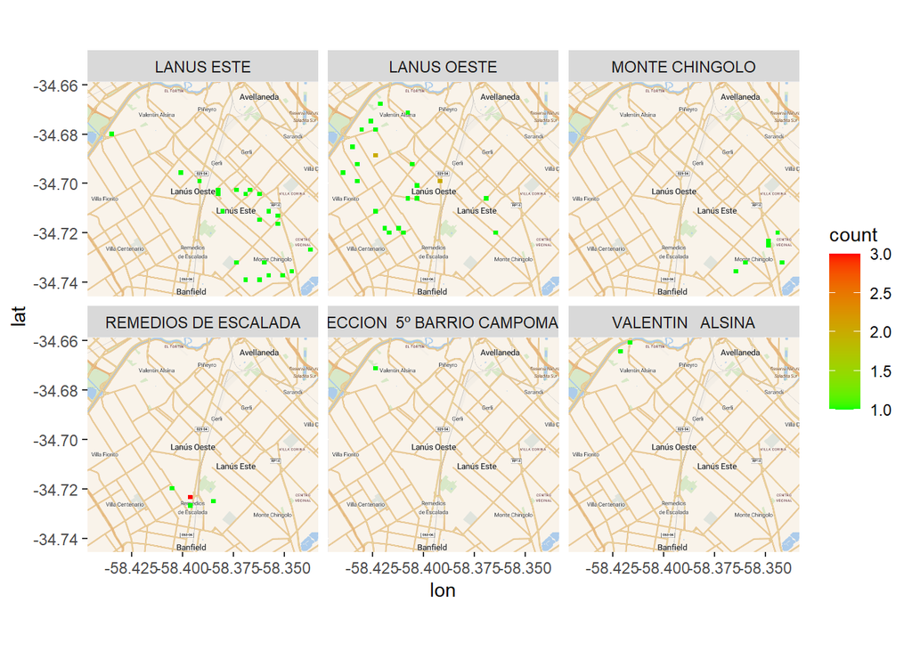

```r
ggmap(mapa_Lanus) +
  geom_bin2d(data = hospitales_Lanus,
             aes(x = long, y = lat), bins = 50) +
  scale_fill_gradient(low = "green", high = "red") +
  facet_wrap(~nba)
```

Vamos a ver un mapa interactivo para ver la ubicación de los establecimientos en el partido de Lanús.

```r
leaflet(hospitales_Lanus) %>%
  addProviderTiles(providers$CartoDB.Positron) %>%
  addMarkers(~long, ~lat,
             popup = ~nor)
```

[interactive chart not shown]

Recordemos donde esta ubicado el barrio de Villa Jardín;

```r
leaflet(villa_Jardin) %>%
  addProviderTiles("CartoDB.Positron") %>%
  addPolygons(popup = "Villa Jardín")
```

[interactive chart not shown]

Aqui contamos el número de establecimientos de salud por localidad dentro del partido de Lanús.

```r
hospitales_Lanus_count <- hospitales_Lanus %>%
  count(nba) %>%
  group_by(nba) %>%
  mutate(localidad_total_hosp= sum(n))
```

```r
hospitales_Lanus_count
```

```
## # A tibble: 6 × 3
## # Groups:   nba [6]
##   nba                             n localidad_total_hosp
##   <fct>                       <int>                <int>
## 1 LANUS ESTE                     22                   22
## 2 LANUS OESTE                    24                   24
## 3 MONTE CHINGOLO                  6                    6
## 4 REMEDIOS DE ESCALADA            6                    6
## 5 SECCION  5º BARRIO CAMPOMAR     1                    1
## 6 VALENTIN   ALSINA               2                    2
```

y lo visualizamos.

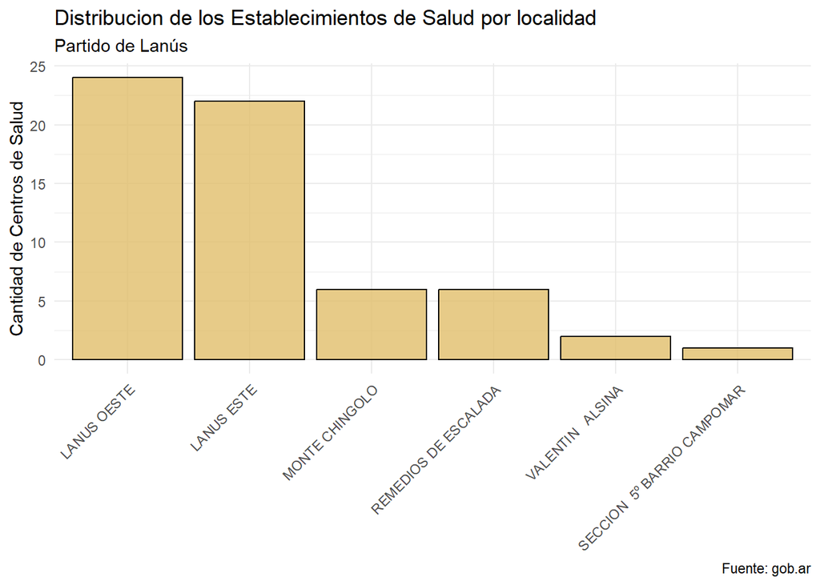

```r
  ggplot(hospitales_Lanus_count, aes(x= reorder(nba, -localidad_total_hosp),
                                  y=n))+
  geom_col(fill = "#E1BE6A", alpha = 0.8, color = "black") +
    labs(
    title = "Distribucion de los Establecimientos de Salud por localidad",
    subtitle = "Partido de Lanús",
    x = NULL,
    y = "Cantidad de Centros de Salud",
    caption = "Fuente: gob.ar"
  ) +
   theme_minimal() +
  theme(axis.text.x = element_text(angle = 45, hjust = 1))
```

Como dijimos antes, Lanús Oeste y Lanús Este son las localidades que tienen el mayor número de establecimientos de salud.

Volvemos al dataset espacial mostrando las geometrías de Villa Jardín.

```r
villa_Jardin
```

```
## Simple feature collection with 1 feature and 17 fields
## Geometry type: MULTIPOLYGON
## Dimension:     XY
## Bounding box:  xmin: -58.43537 ymin: -34.68052 xmax: -58.4249 ymax: -34.67061
## Geodetic CRS:  WGS 84
##   id_renabap nombre_barrio    provincia departamento   localidad
## 1       1012  Villa Jardín Buenos Aires        Lanús Lanús Oeste
##   cantidad_viviendas_aproximadas cantidad_familias_aproximada
## 1                           4500                         4950
##   decada_de_creacion anio_de_creacion           energia_electrica
## 1        Década 1940               NA Conexión irregular a la red
##                      efluentes_cloacales                      agua_corriente
## 1 Desagüe sólo a pozo negro/ciego u hoyo Conexión irregular a la red de agua
##           cocina       calefaccion titulo_propiedad clasificacion_barrio
## 1 Gas en garrafa Energía eléctrica               NO                Villa
##   superficie_m2                           geom
## 1        426815 MULTIPOLYGON (((-58.4309 -3...
```

Como estoy trabajando en un multipolígono, para obtener un punto de origen para poder calcular las Isócronas tuve que calcular el centroide del multipolígono

```r
centroide <- st_centroid(villa_Jardin)
coords <- st_coordinates(centroide)
coords
```

```
##              X         Y
## [1,] -58.43086 -34.67634
```

Estas serían las coordenadas del centro geográfico de Villa Jardín.

**Analisis de distancias**

El próximo paso es analizar las distancias mediante Isócronas para evaluar la accesibilidad a los Centros de Salud ubicados a menos de 20 minutos del centro geográfico de Villa Jardín.

```r
isocrona <- osrmIsochrone(loc = c(coords[1, "X"], coords[1, "Y"]),
                     breaks = seq(from=0,to=20,by=5),
                     res = 35,
                     osrm.profile = "foot")
```

Resultado del análisis:

```r
isocrona
```

```
## Simple feature collection with 4 features and 3 fields
## Geometry type: MULTIPOLYGON
## Dimension:     XY
## Bounding box:  xmin: -58.44108 ymin: -34.68861 xmax: -58.41775 ymax: -34.66522
## Geodetic CRS:  WGS 84
##   id isomin isomax                       geometry
## 1  1      0      5 MULTIPOLYGON (((-58.4291 -3...
## 2  2      5     10 MULTIPOLYGON (((-58.42734 -...
## 3  3     10     15 MULTIPOLYGON (((-58.42913 -...
## 4  4     15     20 MULTIPOLYGON (((-58.42614 -...
```

Lo visualizamos.

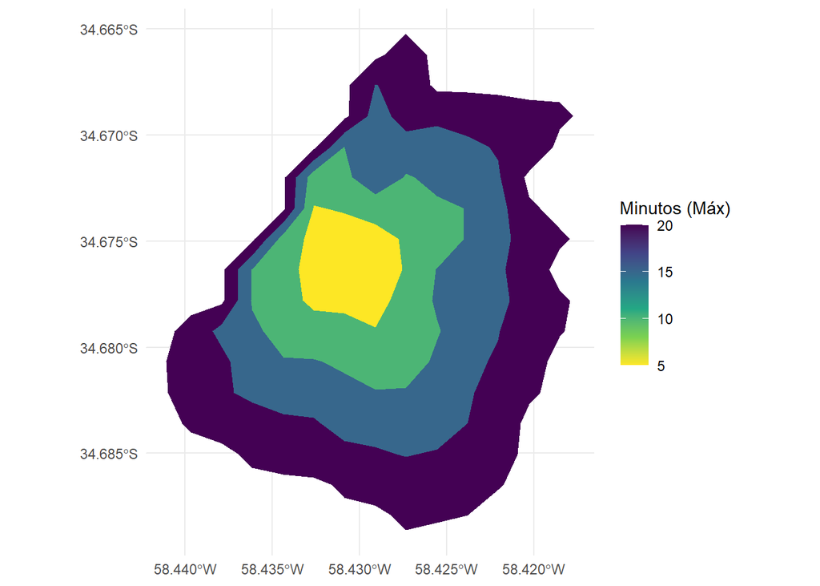

```r
ggplot()+
  geom_sf(data=isocrona, aes(fill=isomax), color=NA)+
  scale_fill_viridis_c(direction=-1)+
  labs(fill="Minutos (Máx)")+
  theme_minimal()
```

Vemos las áreas en las que se encuentran a 20, 15,10 y 5 minutos respectivamente.

Al mapa de Isócronas le agregamos la ubicación del centro geográfico de Villa Jardín.

```r
leaflet(isocrona) %>%
  addProviderTiles(providers$CartoDB.Positron) %>%
  addPolygons(fillColor = ~colorBin("YlOrRd", domain = isocrona$isomax)(isomax),
  color = NA,
  fillOpacity = 0.5) %>%
  addMarkers(data=centroide)%>%
  addMiniMap(tiles=providers$CartoDB.Positron)
```

[interactive chart not shown]

Encontremos cuantos establecimientos de salud se encuentran dentro de las isócronas calculadas.

¿Cuál es el CRS de las isócronas?

```r
st_crs(isocrona)
```

```
## Coordinate Reference System:
##   User input: EPSG:4326
##   wkt:
## GEOGCRS["WGS 84",
##     ENSEMBLE["World Geodetic System 1984 ensemble",
##         MEMBER["World Geodetic System 1984 (Transit)"],
##         MEMBER["World Geodetic System 1984 (G730)"],
##         MEMBER["World Geodetic System 1984 (G873)"],
##         MEMBER["World Geodetic System 1984 (G1150)"],
##         MEMBER["World Geodetic System 1984 (G1674)"],
##         MEMBER["World Geodetic System 1984 (G1762)"],
##         MEMBER["World Geodetic System 1984 (G2139)"],
##         MEMBER["World Geodetic System 1984 (G2296)"],
##         ELLIPSOID["WGS 84",6378137,298.257223563,
##             LENGTHUNIT["metre",1]],
##         ENSEMBLEACCURACY[2.0]],
##     PRIMEM["Greenwich",0,
##         ANGLEUNIT["degree",0.0174532925199433]],
##     CS[ellipsoidal,2],
##         AXIS["geodetic latitude (Lat)",north,
##             ORDER[1],
##             ANGLEUNIT["degree",0.0174532925199433]],
##         AXIS["geodetic longitude (Lon)",east,
##             ORDER[2],
##             ANGLEUNIT["degree",0.0174532925199433]],
##     USAGE[
##         SCOPE["Horizontal component of 3D system."],
##         AREA["World."],
##         BBOX[-90,-180,90,180]],
##     ID["EPSG",4326]]
```

Tranformamos el dataset de hospitales Lanús a geográfico.

```r
hospitales_geo <- hospitales_Lanus %>%
  st_as_sf(coords=c("long", "lat"), crs=4326)
```

Desactivamos la función de geometría esférica.

```r
sf_use_s2(FALSE)
```

```
## Spherical geometry (s2) switched off
```

y vemos el resultado.

```r
head(hospitales_geo)
```

```
## Simple feature collection with 6 features and 18 fields
## Geometry type: POINT
## Dimension:     XY
## Bounding box:  xmin: -58.43125 ymin: -34.73142 xmax: -58.34468 ymax: -34.67743
## Geodetic CRS:  WGS 84
##     id                                                                 cat
## 1 1452                                                            C.A.P.S.
## 2 1453                                                            C.A.P.S.
## 3 1454                                                            C.A.P.S.
## 4 1455 ESTABLECIMIENTO POLIVALENTE CON INTERNACION Y PRESTACIÓN QUIRURGICA
## 5 1456                                                            C.A.P.S.
## 6 1457                   CENTRO DE SALUD MENTAL Y/O CONSUMOS PROBLEMATICOS
##                                                              nor      cpd
## 1                                  CENTRO DE SALUD VILLA URQUIZA 43400014
## 2                                   CENTRO DE SALUD VILLA OBRERA 43400022
```

[output cut: 32 more lines]

Realizamos la intersección de ambos datasets para ver el número de centros de salud que se solapan con la isócrona calculada.

```r
hospitales_geo <- st_intersection(hospitales_geo, isocrona)
```

```
## although coordinates are longitude/latitude, st_intersection assumes that they
## are planar
```

```r
hospitales_geo
```

```
## Simple feature collection with 6 features and 21 fields
## Geometry type: POINT
## Dimension:     XY
## Bounding box:  xmin: -58.43489 ymin: -34.68492 xmax: -58.42272 ymax: -34.67086
## Geodetic CRS:  WGS 84
##      id      cat                                nor      cpd         cnr cde
## 3  1454 C.A.P.S.      UNIDAD SANITARIA VILLA JARDIN 43400031 5,00643E+13 434
## 46 1497 C.A.P.S. CENTRO DE SALUD VILLA CONSTITUCION 43401410 5,00643E+13 434
## 15 1466 C.A.P.S.       CENTRO DE SALUD EL TRIANGULO 43400308 5,00643E+13 434
## 29 1480 C.A.P.S.                              UPA 3 43401023 5,00643E+13 434
## 45 1496 C.A.P.S. CENTRO DE SALUD Y FOMENTO CAMPOMAR 43401401 5,00643E+13 434
## 9  1460 C.A.P.S.     CENTRO DE SALUD VILLA GIARDINO 43400201 5,00643E+13 434
##      nde                     dom                         nba nrs  cp1
## 3  LANUS  EMILIO CASTRO 3826   0                 LANUS OESTE  VI 1824
## 46 LANUS       VIAMONTE 3846   0                 LANUS OESTE  VI 1824
```

[output cut: 25 more lines]

```r
dim(hospitales_geo)
```

```
## [1]  6 22
```

Existen 6 unidades y centros de salud ubicados a menos de 20 minutos a pié del punto central de Villa Jardín.

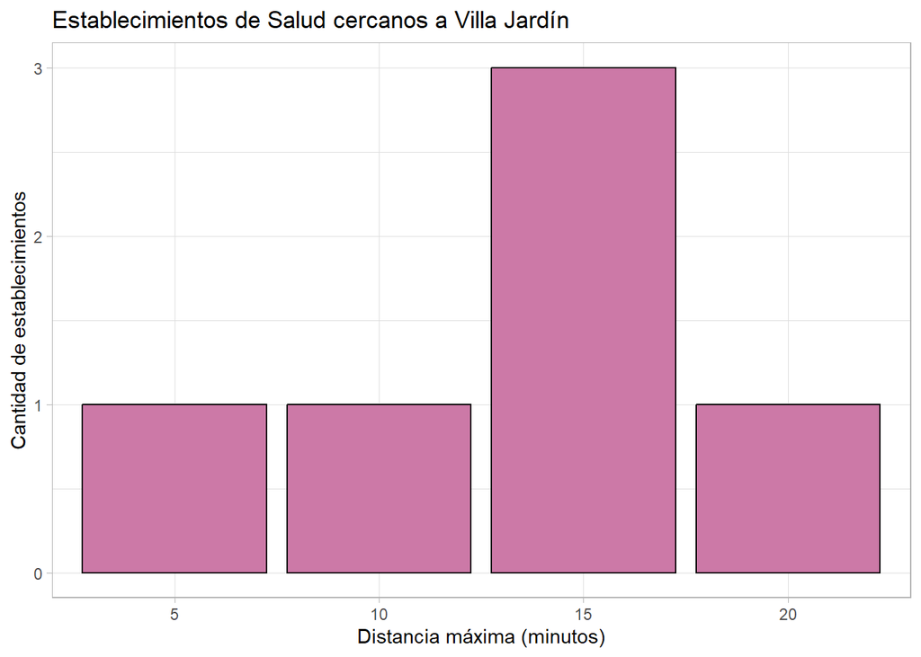

```r
ggplot()+
  geom_bar(data=hospitales_geo, aes(x=as.factor(isomax)), fill="#CC79A7", color="black")+
  labs(title="Establecimientos de Salud cercanos a Villa Jardín",
       x="Distancia máxima (minutos)",
       y="Cantidad de establecimientos")+
  theme_light()
```

Podemos ver que solamente hay un centro de salud a 5 minutos a pié y la mayoría esta a 15 minutos.

Veamos un mapa interactivo.

```r
leaflet(isocrona) %>%
  addProviderTiles(providers$CartoDB.Positron) %>%
  addPolygons(fillColor = ~colorBin("YlOrRd", domain = isocrona$isomax)(isomax),
  color = NA,
  fillOpacity = 0.5) %>%
  addMarkers(data=centroide,
             popup = "Villa Jardín") %>%
  addCircles(data=hospitales_geo,
             popup = ~nor,
             color = "black")%>%
  addMiniMap(tiles=providers$CartoDB.Positron)
```

[interactive chart not shown]

**Calculemos las distancias y duraciones de los centros/Unidades de salud de Villa Jardín**

Para visualizarlo en un mapa, debemos convertirla en un dataframe.

```r
class(coords)
```

```
## [1] "matrix" "array"
```

```r
coords <- data.frame(X = -58.43086, Y = -34.67634)
```

Vemos si la estructura de datos cambio.

```r
class(coords)
```

```
## [1] "data.frame"
```

Calcularemos la distancia y duración de todos los centros/unidades sanitarios que se encuentren a menos de 20 minutos a pié

Utilizaremos la función osrmRoute ().

```r
ruteo_función <- function(nombre_origen, lon_origen, lat_origen,
                          nombre_destino, lon_destino, lat_destino)
  {
  ruta <- osrmRoute(src = c(lon_origen, lat_origen),
                    dst = c(lon_destino, lat_destino),
                    overview = "full",
                    osrm.profile = "foot")

  ruta %>%
  mutate(src=nombre_origen,
         dst=nombre_destino)
}
```

Transformamos el dataset espacial a tradicional para utilizar longitud y latitud.

```r
hospitales_geo <- hospitales_geo %>%
  mutate(long = st_coordinates(.)[,1],
         lat  = st_coordinates(.)[,2]) %>%
  st_drop_geometry()
```

```r
hospitales_geo
```

```
##      id      cat                                nor      cpd         cnr cde
## 3  1454 C.A.P.S.      UNIDAD SANITARIA VILLA JARDIN 43400031 5,00643E+13 434
## 46 1497 C.A.P.S. CENTRO DE SALUD VILLA CONSTITUCION 43401410 5,00643E+13 434
## 15 1466 C.A.P.S.       CENTRO DE SALUD EL TRIANGULO 43400308 5,00643E+13 434
## 29 1480 C.A.P.S.                              UPA 3 43401023 5,00643E+13 434
## 45 1496 C.A.P.S. CENTRO DE SALUD Y FOMENTO CAMPOMAR 43401401 5,00643E+13 434
## 9  1460 C.A.P.S.     CENTRO DE SALUD VILLA GIARDINO 43400201 5,00643E+13 434
##      nde                     dom                         nba nrs  cp1
## 3  LANUS  EMILIO CASTRO 3826   0                 LANUS OESTE  VI 1824
## 46 LANUS       VIAMONTE 3846   0                 LANUS OESTE  VI 1824
## 15 LANUS   CNEL. OSORIO 2099   0                 LANUS OESTE  VI 1824
## 29 LANUS OSORIO 25 DE MAYO  3000                  LANUS ESTE  VI 1824
## 45 LANUS    BALCARCE N° 3846   0 SECCION  5º BARRIO CAMPOMAR  VI 1824
## 9  LANUS        ARMENIA 3114   0                 LANUS OESTE  VI 1824
##                 tel                           mai        tes Com
```

[output cut: 20 more lines]

Asignamos un vector para el input.

```r
ruteo2 <- list("Unidad de Salud", coords$X, coords$Y,
               hospitales_geo$nor, hospitales_geo$long, hospitales_geo$lat)
```

```r
ruteo2 <- pmap(ruteo2, ruteo_función)
```

```r
summary(ruteo2)
```

```
##      Length Class Mode
## [1,] 5      sf    list
## [2,] 5      sf    list
## [3,] 5      sf    list
## [4,] 5      sf    list
## [5,] 5      sf    list
## [6,] 5      sf    list
```

```r
ruteo2 <- ruteo2 %>%
  reduce(rbind)
```

```r
summary(ruteo2)
```

```
##      src                                            dst       duration
##  Length:6           CENTRO DE SALUD EL TRIANGULO      :1   Min.   : 2.828
##  Class :character   CENTRO DE SALUD VILLA CONSTITUCION:1   1st Qu.: 8.140
##  Mode  :character   CENTRO DE SALUD VILLA GIARDINO    :1   Median :10.842
##                     CENTRO DE SALUD Y FOMENTO CAMPOMAR:1   Mean   :10.649
##                     UNIDAD SANITARIA VILLA JARDIN     :1   3rd Qu.:13.624
##                     UPA 3                             :1   Max.   :17.592
##                     (Other)                           :0
##     distance               geometry
##  Min.   :0.2120   LINESTRING   :6
##  1st Qu.:0.6106   epsg:4326    :0
##  Median :0.8132   +proj=long...:0
##  Mean   :0.7978
##  3rd Qu.:1.0218
##  Max.   :1.3142
##
```

Podemos observar lo siguiente:

- La duración promedio es de 10,64 minutos y la distancia promedio es de 0,79km.
- El recorrido más corto es de 0,21km y el más largo de 1,31km.
- El recorrido de menor duración es en 2,82 min y el de mayor es de 17,59 min.

¿Cuál es el Centro Sanitario ubicado a 5 minutos a pié y a que distancia?

```r
hospitales1 <- hospitales_geo %>%
  filter(isomax==5)
```

```r
hospitales1
```

```
##     id      cat                           nor      cpd         cnr cde   nde
## 1 1454 C.A.P.S. UNIDAD SANITARIA VILLA JARDIN 43400031 5,00643E+13 434 LANUS
##                      dom         nba nrs  cp1              tel
## 1 EMILIO CASTRO 3826   0 LANUS OESTE  VI 1824 11 42089841 Int:
##                             mai       tes Com                 Dep
## 1 secsalud@lanus.mun.gba.gov.ar Municipal     Secretaria de Salud
##                           mod     Esp id.1 isomin isomax      long       lat
## 1 ASISTENCIAL SIN INTERNACION GENERAL    1      0      5 -58.43125 -34.67743
```

y el centro mas lejano:

```r
hospitales18 <- hospitales_geo %>%
  filter(isomax==20)
```

```r
head(hospitales18)
```

```
##     id      cat                            nor      cpd         cnr cde   nde
## 1 1460 C.A.P.S. CENTRO DE SALUD VILLA GIARDINO 43400201 5,00643E+13 434 LANUS
##                dom         nba nrs  cp1              tel mai       tes Com
## 1 ARMENIA 3114   0 LANUS OESTE  VI 1824 11 42086659 Int:     Municipal
##                   Dep                         mod     Esp id.1 isomin isomax
## 1 Secretaria de Salud ASISTENCIAL SIN INTERNACION GENERAL    4     15     20
##        long       lat
## 1 -58.43407 -34.68492
```

El centro mas lejano es el Centro de Salud Villa Giardino ubicado en Armenia 3114 situado a 1,31km y a 18 minutos caminando.

Visualizemos en el mapa los recorridos de los 6 centros sanitarios situados a menos de 20 minutos a pié.

```r
leaflet(ruteo2) %>%
    addProviderTiles(providers$CartoDB.DarkMatter) %>%
    addPolylines(color = "#D55E00",
                 label = paste("Distancia:", ruteo2$distance, "|",
                               "Duración:", ruteo2$duration))%>%
  addCircleMarkers(data=coords, ~X, ~Y,
                   popup = "Villa Jardín",
                   color="white") %>%
  addCircleMarkers(data=hospitales_geo, ~long, ~lat,
                   popup = ~nor,
                   color="gray") %>%
  addMiniMap(tiles=providers$CartoDB.DarkMatter)
```

[interactive chart not shown]

**Conclusión**

A raíz de este proyecto, y para contextualizar, se evidencia que la mayor distribución de barrios populares se concentra principalmente en la provincia de Buenos Aires, seguida en menor medida por las provincias de Santa Fe y Chaco. En estas provincias, la tipología predominante de barrios populares son los asentamientos informales.

Dentro de la provincia de Buenos Aires, cabe enfatizar que la Zona Sur alberga las localidades con mayor cantidad de barrios populares que superan las 3000 familias por barrio. Es el caso de Lomas de Zamora, seguido por Quilmes. Asimismo, en la Zona Oeste, destaca el partido de General San Martín.

La respuesta a la segunda pregunta del proyecto se refiere a la accesibilidad del barrio popular a los centros de salud. Cabe mencionar que Villa Jardín cuenta con seis centros o unidades sanitarias a menos de 20 minutos de caminata. La más cercana es la Unidad de Salud Villa Jardín, ubicada exactamente a 2,82 minutos (212 metros), mientras que la más lejana es el Centro de Salud Villa Giardino, que se encuentra a 1,31 km y se tarda aproximadamente 18 minutos en llegar a pie.